# Assessment2-final project

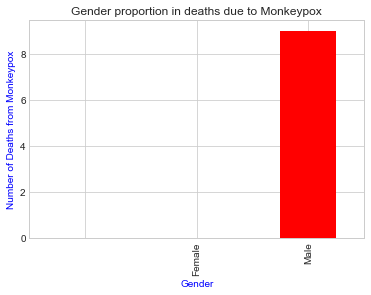

```python
#Finding deaths and gender
falsedata=['22/08/2022', '3/06/2022']
dataFrame['Gender'].replace(falsedata,'0',inplace=True)
dataFrame.groupby('Gender').Date_death.count().plot(kind='bar',color='r')
plt.title('Gender proportion in deaths due to Monkeypox')
plt.xlabel('Gender', color='b')
plt.ylabel('Number of Deaths from Monkeypox', color='b')
```

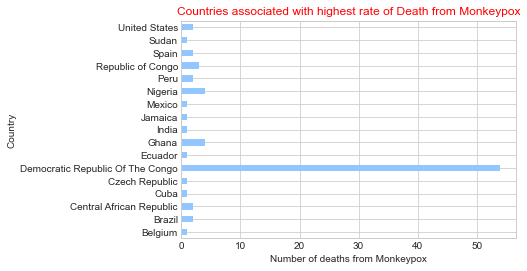

```python
# importing libraries
import pandas as pd
import matplotlib.pyplot as plt
%matplotlib inline
# Tidying the data column
Deaths=dataFrame[dataFrame['Date_death'].notnull()]
# Grouping and selecting needed data. Selecting to plot horizontal bvar graph.
graph=Deaths.groupby('Country').Date_death.count().plot(kind='barh')
# Choosing style and filling characteristics of the graph.
plt.style.use('seaborn-whitegrid')
plt.xlabel('Number of deaths from Monkeypox')
plt.title('Countries associated with highest rate of Death from Monkeypox',color='r')sss
```

In the graph of 'Countries associated with highest rate of Death from Monkeypox', we can see that Democratic Republic of The Congo' sits on top with 54 person dead from Monkeypox out of 83 worldwide. We can see that other African Countries are next in number of deaths.Also, though US have very high number of cases of Monkeypox, but fortunately Mortality from Monkeypox is quite low there. The high Mortality from Monkeypox in African countries, especially Democratic Republic of The Congo is very obvious in the graph. This invites further research to find the reason of this disproportion. I will investigate if poverty in countries are related to number of deaths from Monkeypox. To do this, I will import and read a csv file that shows rate of poverty in different countries . This data is sourced from World Bank data on global economy.The link to this data is https://worldpopulationreview.com/country-rankings/poverty-rate-by-country.

```
                          %Poverty  dataYear  lessthan10USD  lessthan5.50USD  \
country
DR Congo                      63.9      2012          99.39            96.78
Ghana                         23.4      2016          78.45            50.27
Central African Republic      62.0      2008          97.78            94.26
Nigeria                       40.1      2018          98.76            92.04
Mexico                        41.9      2018          55.77            22.96
Republic of the Congo         40.9      2011          97.29            91.94
Spain                         20.7      2018           6.55             2.40
Sudan                         46.5      2009          95.98            80.69
United States                 17.8      2018           2.75             1.75
Peru                          20.2      2019          48.36            20.57
Belgium                       14.8      2018           0.42             0.16
Jamaica                       19.9      2012          62.01            29.93
India                         21.9      2011            NaN              NaN
Brazil                        26.5      2018          39.66            19.62
Ecuador                       25.0      2019          52.99            25.39
Czech Republic                10.1      2018            NaN              NaN

                          Monkeypox_deaths
country
DR Congo                                54
Ghana                                    4
Central African Republic                 2
Nigeria                                  4
Mexico                                   1
Republic of the Congo                    3
Spain                                    2
Sudan                                    1
United States                            2
Peru                                     2
Belgium                                  1
Jamaica                                  1
India                                    1
Brazil                                   2
Ecuador                                  1
Czech Republic                           1
```

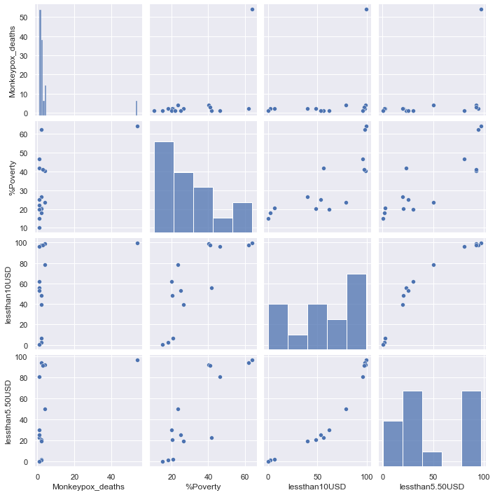

```python
# importing libraries
import csv
import pandas as pd
import matplotlib.pyplot as plt
import seaborn as sns
%matplotlib inline

# reading both files with csv
poverty_data=pd.read_csv(r"C:\Users\dzoha\Downloads\WHO POVERTY DATA.csv",low_memory=False)
dataFrame=pd.read_csv(r"C:\Users\dzoha\OneDrive\Documents\monkeypox_df.csv",low_memory=False)

# Extracting Monkeypox death in different country information from Global Monkeypox Data file
Monkeypox_deaths=dataFrame.groupby('Country').Date_death.count().dropna()

# tidying data
df=Monkeypox_deaths.loc[(Monkeypox_deaths!=0)]
# From global poverty data, slicing the dataframe with the help of index, to get data for
#only those countries where people have died from Monkeypox, as per our monkeypox data file.

Poverty_related_data=poverty_data.iloc[[7,76,8,36,30,34,90,24,104,93,120,96,82,57,64,140]]
Poverty_related_data.reset_index(drop=True,inplace=True)

# adding new column of number of deaths for each country in the new selected dataframe

data=Poverty_related_data.assign(Monkeypox_deaths=[54,4,2,4,1,3,2,1,2,2,1,1,1,2,1,1])

# setting dataframe index to country

new_dataFrame=data.set_index('country')

# Changing column names to suitable ones

new_dataFrame.rename(columns={'percPoverty':"%Poverty"}, inplace=True)
new_dataFrame.rename(columns={'lessThan10': 'lessthan10USD','lessThan550':'lessthan5.50USD'},inplace=True)

# to display the dataframe from ehich pairplot will be constructed to show correlation.
print(new_dataFrame)

# plotting a pairplot with the help of seaborn library to find any correlation between number of monkeypox deaths and and poverty in Monkeypox affected countries.
sns.set()
sns.pairplot(new_dataFrame[['Monkeypox_deaths','%Poverty','lessthan10USD', 'lessthan5.50USD']])
```

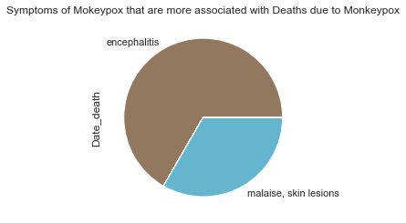

```python
# plotting a graph between recorded symptoms and death ,
#only few of patients that died of Monkepox had their symptoms recorded, the viualisation of which is as follows.
plt.title('Symptoms of Mokeypox that are more associated with Deaths due to Monkeypox')
dataFrame.groupby('Symptoms').Date_death.count().plot(kind='pie')
```

```python
# All Monkeypox ppatients with encephalitis recorded in the data has died.
dataFrame[dataFrame['Symptoms']=='encephalitis']
#This shows that there were two cases with encephalitis and both of them died, making encephalitis be knows as a lethal symptom of Monkeypox.
```

|  | Unnamed: 0 | Status | Location | City | Country | Country_ISO3 | Age | Gender | Date_onset | Date_confirmation | ... | Source | Source_II | Source_III | Source_IV | Source_V | Source_VI | Source_VII | Date_entry | Date_death | Date_last_modified |
| --- | --- | --- | --- | --- | --- | --- | --- | --- | --- | --- | --- | --- | --- | --- | --- | --- | --- | --- | --- | --- | --- |
| 23624 | N23624 | confirmed | Andalusia | NaN | Spain | ESP | 30-34 | Male | NaN | 30/07/2022 | ... | https://abcnews.go.com/Health/wireStory/spain-... | https://twitter.com/saludand/status/1553364825... | NaN | NaN | NaN | NaN | NaN | 1/08/2022 | 30/07/2022 | 1/08/2022 |
| 23625 | N23625 | confirmed | Valencian Community | NaN | Spain | ESP | 40-44 | Male | NaN | 29/07/2022 | ... | https://www.faz.net/aktuell/gesellschaft/gesun... | https://abcnews.go.com/Health/wireStory/spain-... | NaN | NaN | NaN | NaN | NaN | 1/08/2022 | 29/07/2022 | 1/08/2022 |

2 rows × 36 columns

```python
Encephalitis(Brain inflammation) is the nmost fatal symptom of Monkeypox.
```

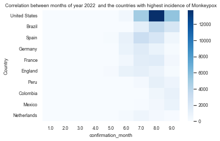

```python
# importing libraries
import csv
import pandas as pd
import matplotlib.pyplot as plt
%matplotlib inline
import datetime

# reading data
dataFrame=pd.read_csv(r"C:\Users\dzoha\OneDrive\Documents\monkeypox_df.csv",low_memory=False)

# diving date column into month and year
dataFrame['Date_confirmation']=pd.to_datetime(dataFrame.Date_confirmation,format='%d/%m/%Y')
dataFrame['confirmation_month']=dataFrame['Date_confirmation'].dt.month

# tidying data
falsedata=[11.0,12.0]
dataFrame['confirmation_month'].replace(falsedata,6.0, inplace=True)

#extracting needed data

coll3=dataFrame.groupby('Country').confirmation_month.value_counts().sort_values(ascending=False).unstack().fillna(0)

# importing library to plot the heatmap.
import seaborn as sns

# setting for plotting heatmap
sns.set(font_scale=0.8)
sns.heatmap(data=coll3.head(10),cmap="Blues")
plt.title('Correlation between months of year 2022  and the countries with highest incidence of Monkeypox')
```

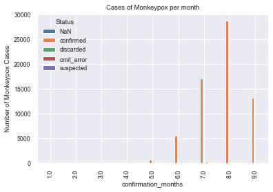

```python
# to get cases of monkeypox per month
# tidying data

falsedata=['https://www.publichealthontario.ca/-/media/Documents/M/2022/monkeypox-episummary.pdf?sc_lang=en']
dataFrame['Status'].replace(falsedata,'NaN', inplace=True)

# selecting needed data and plotting in the graph
df=dataFrame.groupby('confirmation_month').Status.value_counts().unstack().fillna(0).plot(kind='bar')

#Labelling the graph
plt.title('Cases of Monkeypox per month')
plt.xlabel('confirmation_months')
plt.ylabel('Number of Monkeypox Cases')
```

The above graph clearly demonstrate that cases of Monkeypox started appearing in the month of May and increased so much that in August, the incidence of cases rose very high to almost 30,000 cases in that month alone. Luckily, the incidence of cases dropped to almost less than half in Septmeber . Next , we will see the association of travel to different countries with cases of Monkeypox illness.

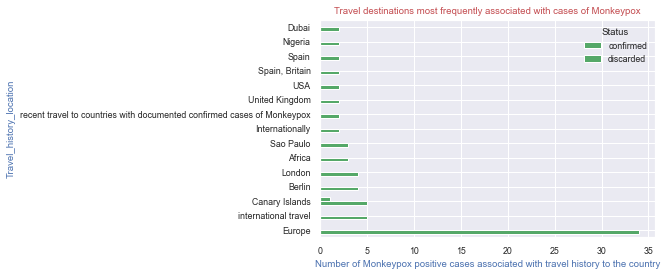

```python
# extracting and tidying suitable parts of data, travel history of confirmed cases of Monkeypox
col1=dataFrame.groupby('Status').Travel_history_location.value_counts().sort_values(ascending=False).unstack().fillna(0)

# transposing dataframe
colp=col1.T # Transposing dataFrame

# sorting confirmed cases in decreasing order
top_travel_cases=colp.sort_values('confirmed',ascending=False)

# plotting
top_travel_cases.head(15).plot(kind='barh',color='g')
plt.title('Travel destinations most frequently associated with cases of Monkeypox',color='r')
plt.xlabel('Number of Monkeypox positive cases associated with travel history to the country',color='b')
plt.ylabel("Travel_history_location", color='b')
```

In the above graph, we can see that travel to Europe is highly associated with cases of Monkeypox illness. Now, we will make a heatmap and see which travel to which countries are related to Monkeypox cases in the Monkeypox affected Countries.

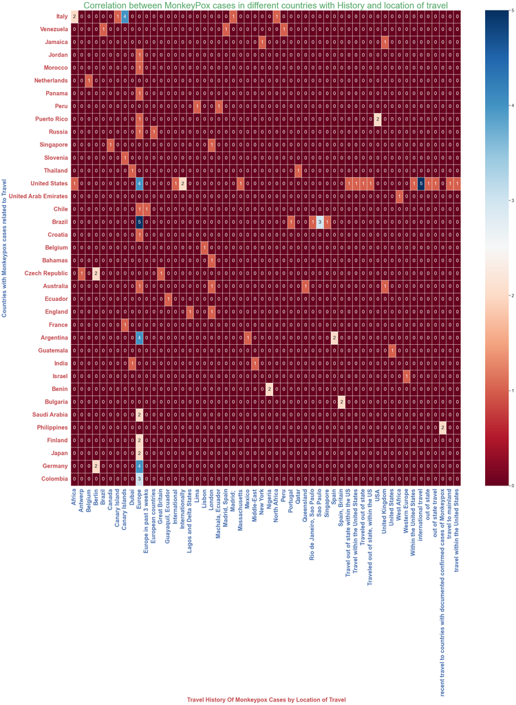

```python
# importing libraries

import csv
import pandas as pd
import matplotlib.pyplot as plt
import seaborn as sns
%matplotlib inline

# reading file
dataFrame=pd.read_csv(r"C:\Users\dzoha\OneDrive\Documents\monkeypox_df.csv",low_memory=False)

# extracting needed data parts
data=dataFrame.groupby('Country').Travel_history_location.value_counts().sort_values().unstack().fillna(0)

#plotting heatmap
fig,bx=plt.subplots(figsize=(30,30))
sns.set(font_scale=1.4)

plt.xticks(rotation=15,ha='center',fontsize=20,color='b',weight='bold')
plt.yticks(label='Countries with Monkeypox Cases', color='r',fontsize=20, weight='bold')
bx=sns.heatmap(data,linewidths=.5,cmap="RdBu",annot=True,fmt='.0f').set_title('Correlation between MonkeyPox cases in different countries with History and location of travel',color='g',fontsize=30)
plt.xlabel(' Travel History Of Monkeypox Cases by Location of Travel', fontsize=20, color='r', weight='bold')
plt.ylabel('Countries with Monkeypox cases related to Travel', color='b', fontsize=20, weight='bold')
```

The heatmap above is a very interesting correlation representation between travel history to different countries and number of Monkeypox cases in the Monkeypox -affected Countries. Lightblue box shows a positive correlation while dark blue box shows a strong correlation. Some interesting observation in this heatmap are that travel to Europe has the most blue boxes and hence most strongly associated with Monkeypox cases Germany, Argentina and Brazil United states .

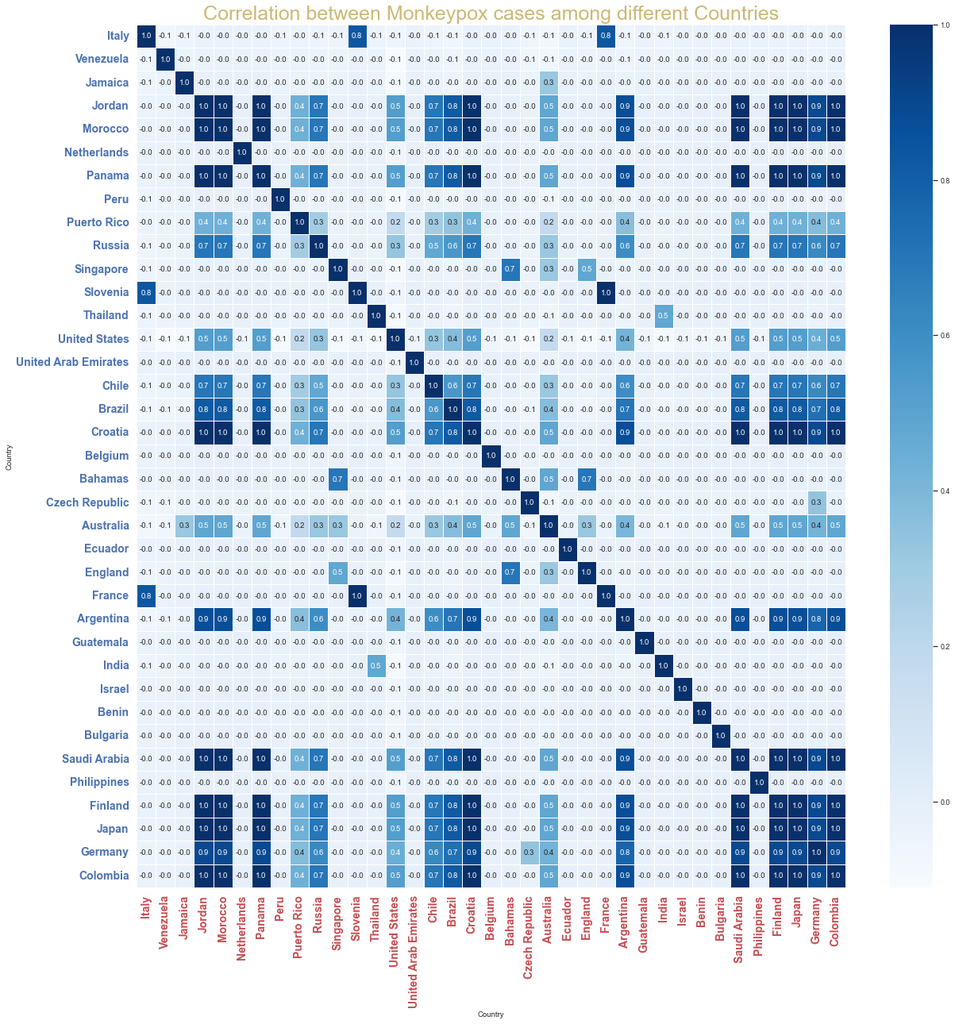

```python
# importing libraries
import csv
import pandas as pd
import matplotlib.pyplot as plt
import seaborn as sns
%matplotlib inline
# reading data
dataFrame=pd.read_csv(r"C:\Users\dzoha\OneDrive\Documents\monkeypox_df.csv",low_memory=False)

# grouping to extraxt suitable data and tidying
data=dataFrame.groupby('Country').Travel_history_location.value_counts().sort_values().unstack().fillna(0)

#plotting heatmap

fig, ax = plt.subplots(figsize=(20,20))
sns.set(font_scale=0.8)
plt.xticks( rotation=15, ha='center', fontsize=14, color='r',weight='bold')
plt.yticks( color='b',fontsize=14,weight='bold')



ax=sns.heatmap(data.T.corr(), linewidths=.5,cmap="Blues",annot=True,fmt='.1f').set_title('Correlation between Monkeypox cases among different Countries',color='y',fontsize=25)
```

This was the notebook of Analysis of Global Monkeypox cases during 2022 Monkeypox Breakout so far. I hope it was informative and interesting. Thank you.